# HW2_PCA_clustering

### Exercise 4: Clustering

So, now that we’ve simplified the complex data set into a lower dimensional space we can visualize and work with, we will use clustering to find patterns in the data, in our case, the aircraft which are most similar?

**(1 point)** Pick the number of components which explain 90% (or a little greater) of the variation and represent the transformed data (projected onto the selected principal components) as `components`

**(1 point)** Using `components` as the input, run k-means for k from `2` to `15` (with `random_state=1`), and visualize SSE by elbow curve.

**(1 point)** Select the best k using elbow curve and run clustering with the selected k to get the cluster assignment

**(Extra credit: 1 point)** Visualize the cluster membership by scatter plots (for each pair of principle components as `x` and `y` axes)

```python
# Pick the number of components which explain 90% (or a little greater) of the variation and represent the transformed data (projected onto the selected principal components) as components
pca = PCA(n_components=3)
components_3 = pca.fit_transform(X_normalized)
```

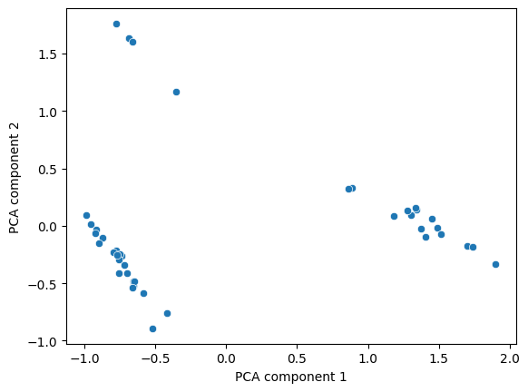

```python
sns.scatterplot(x = components_3[:,0], y=components_3[:,1])
plt.xlabel('PCA component 1')
plt.ylabel('PCA component 2')
```

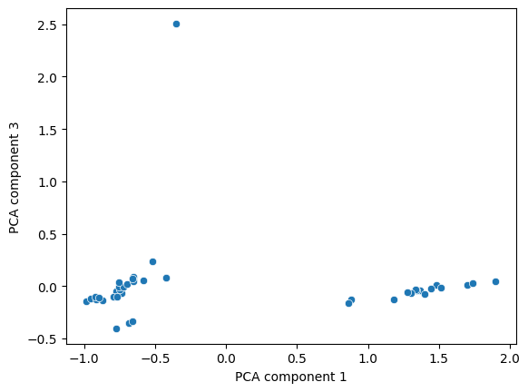

```python
sns.scatterplot(x = components_3[:,0], y=components_3[:,2])
plt.xlabel('PCA component 1')
plt.ylabel('PCA component 3')
```

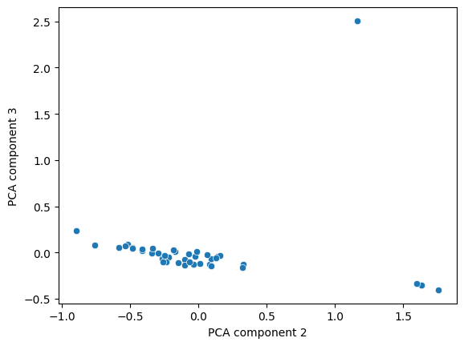

```python
sns.scatterplot(x = components_3[:,1], y=components_3[:,2])
plt.xlabel('PCA component 2')
plt.ylabel('PCA component 3')
```

```python
#Using components as the input, run k-means for k from 2 to 15 (with random_state=1), and visualize SSE by elbow curve.
```

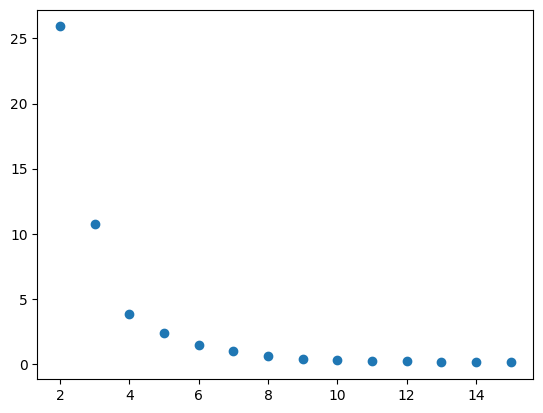

```python
from sklearn.datasets import make_blobs
from sklearn.cluster import KMeans

scores = []

for k in range(2, 16):

    kmeans = KMeans(n_clusters = k)
    # Training the KMeans model on the normalized iris data.
    kmeans.fit(components_3)
    # Appending the negative score of the model to the scores list. The negative sign is used as KMeans returns negative inertia.
    scores.append(-kmeans.score(components_3))

# Plotting the scores for the range of clusters from 1 to 5.
plt.scatter(list(range(2, 16)), scores)
```

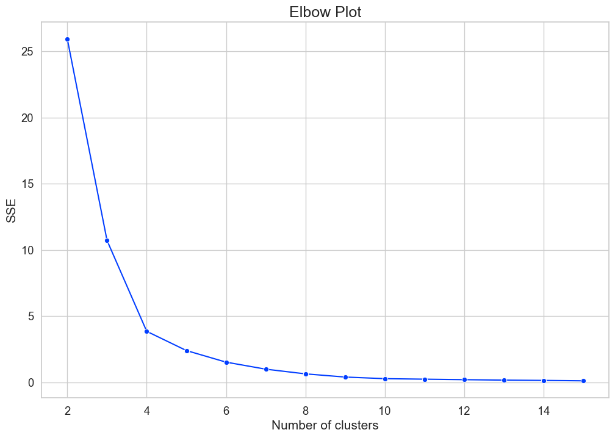

```python
# Function for plotting elbow curve
def plot_elbow_curve(start, end, data):
    no_of_clusters = list(range(start, end+1))
    cost_values = []

    for k in no_of_clusters:
        kmeans = KMeans(n_clusters = k, random_state = 1)
        kmeans.fit_predict(data)
        cost_values.append(kmeans.inertia_)

    sns.set_theme(style="whitegrid", palette="bright", font_scale=1.2)
    plt.figure(figsize=(12, 8))
    ax = sns.lineplot(x=no_of_clusters, y=cost_values, marker="o", dashes=False)
    ax.set_title('Elbow Plot', fontsize=18)
    ax.set_xlabel('Number of clusters', fontsize=15)
    ax.set_ylabel('SSE', fontsize=15)
    plt.plot();

plot_elbow_curve(start=2,end=15,data = components_3)
```

```python
#Select the best k using elbow curve and run clustering with the selected k to get the cluster assignment
```

Based on the elbow plot, we can see that before cluster = 4, the SSE drops a lot, but after cluster = 4, the SSE drops not too much,  
so we choose cluster = 4 as the number of the cluster

```python
kmeans = KMeans(n_clusters = 4)
kmeans.fit(components_3)
```

```
KMeans(n_clusters=4)
```

```python
#Visualize the cluster membership by scatter plots (for each pair of principle components as x and y axes)
```

```python
cluster = kmeans.fit_predict(X)

X['Cluster'] = cluster

X.head()
```

|  | Seat Width (Club) | Seat Pitch (Club) | Seat (Club) | Seat Width (First Class) | Seat Pitch (First Class) | Seats (First Class) | Seat Width (Business) | Seat Pitch (Business) | Seats (Business) | Seat Width (Eco Comfort) | ... | Seat Pitch (Economy) | Seats (Economy) | Accommodation | Cruising Speed (mph) | Range (miles) | Engines | Wingspan (ft) | Tail Height (ft) | Length (ft) | Cluster |
| --- | --- | --- | --- | --- | --- | --- | --- | --- | --- | --- | --- | --- | --- | --- | --- | --- | --- | --- | --- | --- | --- |
| 0 | 0.0 | 0 | 0 | 21.0 | 36.0 | 12 | 0.0 | 0.0 | 0 | 17.2 | ... | 30.5 | 96 | 126 | 517 | 2399 | 2 | 111.83 | 38.583 | 111.00 | 0 |
| 1 | 19.4 | 44 | 12 | 19.4 | 40.0 | 28 | 21.0 | 59.0 | 14 | 0.0 | ... | 0.0 | 0 | 54 | 517 | 3119 | 2 | 111.83 | 38.583 | 111.00 | 1 |
| 2 | 0.0 | 0 | 0 | 21.0 | 36.0 | 12 | 0.0 | 0.0 | 0 | 17.2 | ... | 31.5 | 120 | 150 | 517 | 2420 | 2 | 111.83 | 38.583 | 123.25 | 0 |
| 3 | 0.0 | 0 | 0 | 21.0 | 36.0 | 12 | 0.0 | 0.0 | 0 | 17.2 | ... | 31.5 | 120 | 150 | 517 | 2420 | 2 | 111.83 | 38.583 | 123.25 | 0 |
| 4 | 0.0 | 0 | 0 | 0.0 | 0.0 | 0 | 21.0 | 60.0 | 32 | 18.0 | ... | 30.5 | 181 | 243 | 531 | 6536 | 2 | 197.83 | 59.830 | 188.67 | 3 |

5 rows × 23 columns

```python
X['Cluster'].unique()
```

```
array([0, 1, 3, 2], dtype=int32)
```

```python
n_components = 3
components = pca.fit_transform(X_normalized)[:, :n_components]
```

```python
components
```

```
array([[-0.77466193, -0.21700729, -0.05355604],
       [-0.35226585,  1.16500076,  2.50730036],
       [-0.73733865, -0.2634676 , -0.06844264],
       [-0.73733865, -0.2634676 , -0.06844264],
       [ 1.37047615, -0.02529343, -0.03735896],
       [ 1.48556093, -0.01374743,  0.01117171],
       [ 1.51617041, -0.07366905, -0.01791195],
       [ 1.40183588, -0.09829394, -0.07752105],
       [-0.868668  , -0.10111375, -0.1336597 ],
       [-0.74769565, -0.24559031, -0.03609813],
       [-0.75344767, -0.29498722, -0.00991356],
       [-0.7204656 , -0.34206006, -0.0046536 ],
       [-0.69723216, -0.41366629,  0.01945511],
       [ 1.89965131, -0.33493074,  0.04540639],
       [-0.65290643, -0.51957737,  0.0909585 ],
       [ 0.88393359,  0.32712588, -0.1240362 ],
       [-0.65480761, -0.48044357,  0.05384107],
       [-0.65058242, -0.48190108,  0.04914975],
       [-0.75373969, -0.4109464 ,  0.03478625],
       [-0.6618634 , -0.53679833,  0.07593217],
       [ 0.86292227,  0.32343072, -0.16534424],
       [-0.58495708, -0.58611543,  0.05862966],
       [ 1.18108388,  0.08292413, -0.12922966],
       [ 1.34320516,  0.14019767, -0.04099879],
       [-0.42013889, -0.75781804,  0.07976157],
       [-0.42013889, -0.75781804,  0.07976157],
       [ 1.33255971,  0.15705407, -0.03557833],
       [-0.52110108, -0.89332543,  0.23689738],
       [ 1.30402865,  0.09416289, -0.06425664],
       [ 1.27576751,  0.12907932, -0.05643265],
       [ 1.4471444 ,  0.06133449, -0.02134079],
       [ 1.69964438, -0.17381433,  0.01395651],
       [ 1.73621642, -0.18048987,  0.02911536],
       [-0.68521893,  1.63349135, -0.34940691],
       [-0.68521893,  1.63349135, -0.34940691],
       [-0.98356099,  0.09138576, -0.14223844],
       [-0.95384144,  0.01179537, -0.11491241],
       [-0.77360417,  1.76062425, -0.40421758],
       [-0.91343473, -0.03524607, -0.12917053],
       [-0.91954989, -0.0675653 , -0.10520977],
       [-0.65834354,  1.5984617 , -0.33481665],
       [-0.79362836, -0.2334027 , -0.10538464],
       [-0.76729883, -0.2569345 , -0.09900036],
       [-0.89715117, -0.15006853, -0.10758358]])
```

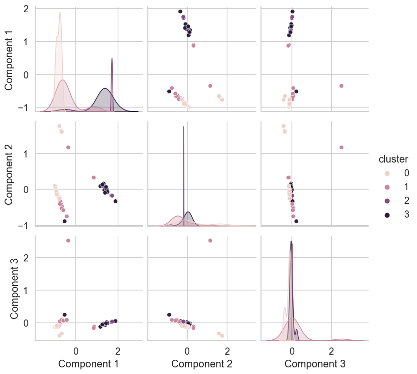

```python
labels = {
    str(i): f"PC {i+1} ({var:.1f}%)"
    for i, var in enumerate(pca.explained_variance_ratio_ * 100)
}

comp_df = pd.DataFrame(components,columns=['Component 1','Component 2','Component 3'])
comp_df['cluster']=X['Cluster']
sns.pairplot(comp_df,hue='cluster')
```

```python
comp_df
```

|  | Component 1 | Component 2 | Component 3 | cluster |
| --- | --- | --- | --- | --- |
| 0 | -0.774662 | -0.217007 | -0.053556 | 0 |
| 1 | -0.352266 | 1.165001 | 2.507300 | 1 |
| 2 | -0.737339 | -0.263468 | -0.068443 | 0 |
| 3 | -0.737339 | -0.263468 | -0.068443 | 0 |
| 4 | 1.370476 | -0.025293 | -0.037359 | 3 |
| 5 | 1.485561 | -0.013747 | 0.011172 | 3 |
| 6 | 1.516170 | -0.073669 | -0.017912 | 3 |
| 7 | 1.401836 | -0.098294 | -0.077521 | 3 |
| 8 | -0.868668 | -0.101114 | -0.133660 | 0 |
| 9 | -0.747696 | -0.245590 | -0.036098 | 1 |
| 10 | -0.753448 | -0.294987 | -0.009914 | 1 |
| 11 | -0.720466 | -0.342060 | -0.004654 | 1 |
| 12 | -0.697232 | -0.413666 | 0.019455 | 1 |
| 13 | 1.899651 | -0.334931 | 0.045406 | 3 |
| 14 | -0.652906 | -0.519577 | 0.090958 | 1 |
| 15 | 0.883934 | 0.327126 | -0.124036 | 1 |
| 16 | -0.654808 | -0.480444 | 0.053841 | 1 |
| 17 | -0.650582 | -0.481901 | 0.049150 | 1 |
| 18 | -0.753740 | -0.410946 | 0.034786 | 1 |
| 19 | -0.661863 | -0.536798 | 0.075932 | 1 |
| 20 | 0.862922 | 0.323431 | -0.165344 | 1 |
| 21 | -0.584957 | -0.586115 | 0.058630 | 1 |
| 22 | 1.181084 | 0.082924 | -0.129230 | 3 |
| 23 | 1.343205 | 0.140198 | -0.040999 | 3 |
| 24 | -0.420139 | -0.757818 | 0.079762 | 1 |
| 25 | -0.420139 | -0.757818 | 0.079762 | 1 |
| 26 | 1.332560 | 0.157054 | -0.035578 | 3 |
| 27 | -0.521101 | -0.893325 | 0.236897 | 3 |
| 28 | 1.304029 | 0.094163 | -0.064257 | 3 |
| 29 | 1.275768 | 0.129079 | -0.056433 | 3 |
| 30 | 1.447144 | 0.061334 | -0.021341 | 3 |
| 31 | 1.699644 | -0.173814 | 0.013957 | 2 |
| 32 | 1.736216 | -0.180490 | 0.029115 | 2 |
| 33 | -0.685219 | 1.633491 | -0.349407 | 0 |
| 34 | -0.685219 | 1.633491 | -0.349407 | 0 |
| 35 | -0.983561 | 0.091386 | -0.142238 | 0 |
| 36 | -0.953841 | 0.011795 | -0.114912 | 0 |
| 37 | -0.773604 | 1.760624 | -0.404218 | 0 |
| 38 | -0.913435 | -0.035246 | -0.129171 | 0 |
| 39 | -0.919550 | -0.067565 | -0.105210 | 0 |
| 40 | -0.658344 | 1.598462 | -0.334817 | 0 |
| 41 | -0.793628 | -0.233403 | -0.105385 | 0 |
| 42 | -0.767299 | -0.256935 | -0.099000 | 0 |
| 43 | -0.897151 | -0.150069 | -0.107584 | 0 |